# R course: Quantitative Linguistics - lesson 1

Danielle Turton

You can *Knit* your document to pdf and Word too.

# Today’s Session

Today, we’re going to be analysing categorical data from the dialect dataset discussed in class. The questions asked as part of this dialect survey should be available in the folder for this lesson.

## Packages

The first thing we want to do before we start is load in the relevant packages for today. The following code should do the job:

```r
## LOAD PACKAGES ####
library(dplyr) # this is a package that makes handling data easier
```

```r
library(ggplot2) # this is a package that makes nice graphs
```

You might see some messages, but that is fine.

However, if this doesn’t work, you may need to install the packages. You only have to install a package once, but you have load a package in (like we just did above) every time you open R. To install a package for the first time, you can go to ** tools > install packages… >** and then search for the name of the package. You can also run it directly through the console by inputting `install.packages("dplyr")`.

## Dialect data

The data itself is in the same folder as this R Notebook document. That means we can easily load it in without having to specify the full path (i.e. location) of the document. Try pressing play on the chunk below to read in the data:

```r
## LOAD IN DATA ####
dialect_data = read.csv("dialectdata.csv")
```

We have called our dataset `dialect_data` and we should now be able to see it in the right corner panel under **Environment** as one of the things we have loaded in.

Let’s look at our data to get a feel for what is in there:

```r
dim(dialect_data)
```

```
## [1] 6596   36
```

How many rows and columns does the data have?

Let’s have a look at the top six rows:

```r
head(dialect_data)
```

```
##      sex      occupation age age_group               town postcode_birth
## 1   male         Retired  82       old          Dunstable            LU6
## 2   male        Designer  24     young       High Wycombe           HP10
## 3   male History Teacher  44    middle          Cambridge            CB3
## 4 female Sales assistant  60    middle           Rainhill            WA2
## 5 female         Retired  65       old Dallam\nWarrington            WA4
## 6   male        Director  63       old Knutsford Cheshire           WA16
##   postcode_now               region          county          bread
## 1       AL4OSR Central Bedfordshire    Bedfordshire            bap
## 2         HP10              Wycombe Buckinghamshire bap, bun, roll
## 3          CB2            Cambridge  Cambridgeshire            bun
## 4          DL2           Warrington        Cheshire           roll
## 5          M40           Warrington        Cheshire            bun
## 6         WA14        Cheshire East        Cheshire           barm
##   furniture clothing evening_meal             group  foot_strut
```

[output cut: 76 more lines]

How about the bottom six?

```r
tail(dialect_data)
```

```
##         sex       occupation age age_group                          town
## 6591 female Store supervisor  19     young                    Billingham
## 6592 female       Accountant  44    middle                 Middlesbrough
## 6593 female          Retired  59    middle                       Glasgow
## 6594 female Process Engineer  23     young        Billingham in Teesside
## 6595 female       House wife  34     young North Cornelly- Mid Glamorgan
## 6596   male          Student  19     young             Old Colwyn, Wales
##      postcode_birth postcode_now           region county          bread
## 6591           TS23         TS23 Stockton-on-Tees                   bun
## 6592           TS15         TS26 Stockton-on-Tees               stottie
## 6593            PA3          TS9     Renfrewshire             bun, roll
## 6594           TS22          WA5 Stockton-on-Tees        barm, bap, bun
## 6595           CF33          WN2         Bridgend                   bap
## 6596           LL29         YO10            Conwy                   bun
##                furniture clothing evening_meal         group  foot_strut
```

[output cut: 83 more lines]

What are the names of the columns?

```r
colnames(dialect_data)
```

```
##  [1] "sex"            "occupation"     "age"            "age_group"
##  [5] "town"           "postcode_birth" "postcode_now"   "region"
##  [9] "county"         "bread"          "furniture"      "clothing"
## [13] "evening_meal"   "group"          "foot_strut"     "for_more"
## [17] "one_gone"       "book_spook"     "fur_bear"       "sauce_source"
## [21] "pour_poor"      "eight_ate"      "bangor_banger"  "mute_moot"
## [25] "spa_spar"       "thin_fin"       "give_it_me"     "I_done_it"
## [29] "it_was"         "you_was"        "beaches_was"    "I_werent"
## [33] "they_was"       "we_was"         "dress_what"     "things_what"
```

Let’s use the `levels()` function from to take a closer look at some of the columns.

```r
# Look at factor levels for some columns
levels(dialect_data$foot_strut)
```

```
## [1] "don't rhyme" "rhyme"
```

```r
levels(dialect_data$give_it_me)
```

```
## [1] "a. I'd say this myself."
## [2] "b. I wouldn't use it, but people from my area do."
## [3] "c. I've heard some people use this form."
## [4] "d. A speaker of English might say this, but I haven't really heard it."
## [5] "e. No native speaker of English would say this."
```

The dollar sign is very important in R, as it references a specific column. For the two columns we’ve referenced in the above example, R shows us the range of possible variants or **factor levels**. For the factor `foot_strut` the possible answers, are therefore factor levels, are `rhyme` and `don't rhyme`. For the factor `give_it_me`, there are five possible answers, as shown by the five factor levels.

Try it yourself on some more variables. Insert a chunk below this line by going to **Insert > R** and running a line of code which will reveal the factor levels of a factor we haven’t looked at yet. Note that factors are for categorical variables, so this won’t work if your variable is continuous.

# Data summaries: Making tables

Let’s say we want to see how many of our respondents have said that “foot” and “strut” rhyme, and how many say they don’t. We can do this easily using the table function in R. Note that we use the dollar sign $ again to denote the specific `foot_strut` column within the `dialect_data` dataset.

```r
table(dialect_data$foot_strut)
```

```
##
## don't rhyme       rhyme
##        3029        3567
```

This would be our dependent variable, but can we think of a possible independent variable we’d want to look at too? We can add this in simply by adding another instruction to the table. Let’s try this with speaker age group (categorical):

```r
table(dialect_data$foot_strut, dialect_data$age_group)
```

```
##
##               middle  old young
##   don't rhyme    956  475  1598
##   rhyme          990  593  1984
```

Note, we also have the specific speaker age (continuous), but that’s going to be difficult to visualise in a table, so we’ll leave that for now.

Try this below for a different independent variable of your choice:

```r
#your code here for your choice of independent variable
```

These numbers are not ideal in terms of presenting a result to our audience. We really want to be showing them the percentage of speakers who say rhyme and don’t rhyme, rather than the raw numbers. How can we do this?

There are always numerous ways to do things in R. Sometimes, I’ll use the functions that come installed with basic R, other times I’ll be showing you additional packages that we can install that will make our lives easier.

### Basic proportional tables

The first step to making a proportional table would be saving our current table as a variable in R.

```r
foot_strut.tab = table(dialect_data$foot_strut, dialect_data$age_group)
```

Once you run this code, you should be able to see your new `foot_strut.tab` in the right hand corner *environment* window. I like to call it R’s brain. You have now saved `foot_strut.tab` in R’s brain and you can call it up whenever you want during the session. Let’s try it now by running the code below:

```r
foot_strut.tab
```

```
##
##               middle  old young
##   don't rhyme    956  475  1598
##   rhyme          990  593  1984
```

Note that I have given it a `.tab` at the end of its name. Once you get going, you’ll have potentially hundreds of things stored in R’s brain. So by giving them names with `.tab` on the end for tables or `.plot` on the end for plots, you’ll make life a bit easier for yourself in the long run.

OK, so how do we make a percentage table, or a proportional table? We can do this with the `prop.table` function:

```r
prop.table(foot_strut.tab, 2)
```

```
##
##                  middle       old     young
##   don't rhyme 0.4912641 0.4447566 0.4461195
##   rhyme       0.5087359 0.5552434 0.5538805
```

This gives us the breakdown in percentages. Is the `foot_strut` variable changing over time between old, middle and young people’s speech?

Let’s save this in R’s brain:

```r
foot_strut.prop.tab = prop.table(foot_strut.tab, 2)
```

What does the `,2` bit mean at the end of the call though? This tells R to divide the proportions using the *second* variable of the table call, not the first. That is, we want to divide each value by the total of the *young, middle and old* columns, and not by the *don’t rhyme/rhyme rows*. We always want to divide by the independent variable. Why is this?

Take a look at what happens when you try to divide by the first variable of the table call:

```r
# WRONG WAY AROUND
prop.table(foot_strut.tab, 1)
```

```
##
##                  middle       old     young
##   don't rhyme 0.3156157 0.1568174 0.5275669
##   rhyme       0.2775442 0.1662461 0.5562097
```

What is wrong with this?

This is a very important thing to remember. We want the independent variable column to be the one that adds up to 100%, to ensure that in cases like these where we have many more participants in one category (young) than another (old) our proportions work our correctly.

Note that, if our original table call had put `age_group` before `foot_strut`, the number would actually be `1`. It’s whatever position the independent variable is in.

Ideally, the table you’ll present to your reader will have percentages in, but also a row below with the totals for each column.

## Making summary tables with `dplyr`

`dplyr` is an R package which makes it very easy to look at summaries of data. Even though some people consider it more advanced, I think it’s a good idea to introduce beginners to it from the start. We’re going to try to do the same using this package.

We already loaded it in at the start, but if you hadn’t have done that by now, the following code would not work. Always make sure you’ve run the line `library(dplyr)` at the beginning of each session to run this kind of code.

`dplyr` makes regular use of this set of symbols, which it calls the *pipe*: `%>%`. This signifies to R that you haven’t finished with your code yet, and it needs to look to the next line to figure out what’s happening next. It’s *piping* the code to the next line. If you get an error message about the pipe `%>%`, it probably means you haven’t loaded in `dplyr`.

```r
dialect_data %>%
  group_by(age_group) %>% # the independent variable
  count(foot_strut) %>% # the dependent variable
  mutate(prop = prop.table(n))
```

```
## # A tibble: 6 x 4
## # Groups:   age_group [3]
##   age_group foot_strut      n  prop
##   <fct>     <fct>       <int> <dbl>
## 1 middle    don't rhyme   956 0.491
## 2 middle    rhyme         990 0.509
## 3 old       don't rhyme   475 0.445
## 4 old       rhyme         593 0.555
## 5 young     don't rhyme  1598 0.446
## 6 young     rhyme        1984 0.554
```

Can you see how this package allows us to do the same thing as we did before, but a bit quicker?

Create a chunk below and try creating some other summaries in `dplyr`. First, let’s create a summary for another independent variable of `foot_strut`:

```r
# here you can look at another independent variable's affect on foot_strut
```

Now let’s try a different independent *and* dependent variable. Insert a new chunk below:

We’ve seen in this section that there’s always (at least!) a couple of ways to do things in R. In the next section we’ll look at making some plots, starting off with the R base graphics, and moving on to some more advanced packages which look more difficult at the beginning, but actually make life easier in the end, and produce much nicer looking plots.

# Plots

## Base R graphics

Let’s try making a plot of the `foot_strut` variable. We can use Base R’s `barplot` function to do this, and it’s useful that we’ve already made tables of the frequencies and proportions.

We could just plot the raw frequencies, but this isn’t very helpful:

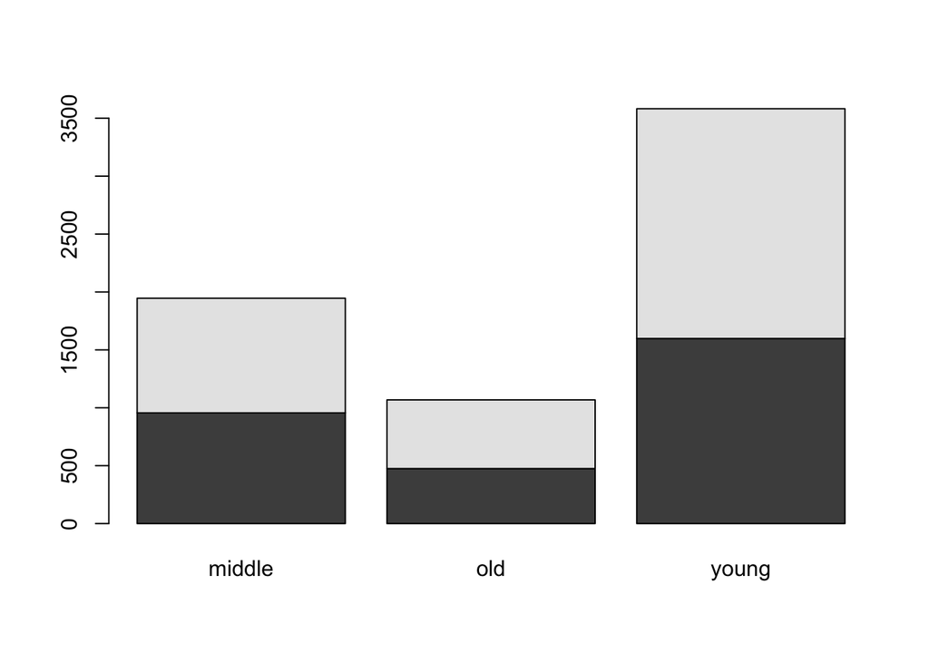

```r
barplot(foot_strut.tab)
```

This graph looks quite rubbish. It’s unclear what the trend is, as our sample is so biased towards young people. Also, it’s annoying for us that R automatically plots factor levels in alphabetical order, because it puts the middle aged group at the front. We’ll come to that in a bit.

Firstly, can you try plotting the proportions instead of the frequencies? Try it in the chunk below, and shout me if you get stuck.

```r
#create a barplot with the proportions of foot_strut instead of raw numbers
```

Can we get it so that it goes in order of age group? Let’s take a look at the factor levels of `age_group` using the levels function:

```r
levels(dialect_data$age_group)
```

```
## [1] "middle" "old"    "young"
```

Can you see that they are in alphabetical order? We can change the order of these levels. Again, there are many ways to do this. We’ll be looking at how you do it in 1) base R and 2) `dplyr`. Firstly, we’ll look at how you do it in base R. In the chunk below, I’ve actually created a new variable called `age_group_ordered`. You don’t have to do this usually, you can just re-specify the order of `age_group`. However, I want to keep the old order to show you how to reorder in `dplyr` too. Saying that, sometimes, if you’re not sure of what you’re doing, it’s better to avoid writing over the old.

Let’s reorder the factor levels:

```r
# reordering
dialect_data$age_group_ordered = factor(dialect_data$age_group,levels(dialect_data$age_group)[c(3, 1, 2)])

#having a look at new order
levels(dialect_data$age_group_ordered)
```

```
## [1] "young"  "middle" "old"
```

Try the plot again with the new order by creating a chunk below:

## Plots in `ggplot2`

Not only do `ggplot2` plots look prettier and are easier to customise, we can also combine them with `dplyr` code to make data changes efficiently. Both packages are written by Hadley Wickham, whose R [style guide](http://adv-r.had.co.nz/Style.html) we discussed earlier in this course.

The package to make ggplots is called `ggplot2`. Remember the `2` when you load in the package, otherwise it won’t work. We already loaded it in before, but you’ll need to do that each time you start R by calling `library(ggplot2)`.

The plot call initially looks a lot more complicated. But `gg` stands for *grammar of graphics*, and as you get used to using it, you’ll realise it’s much easier to switch between different kinds of graphs, and customise the look of them.

Let’s try a barplot for foot_strut and age_group in `ggplot2`:

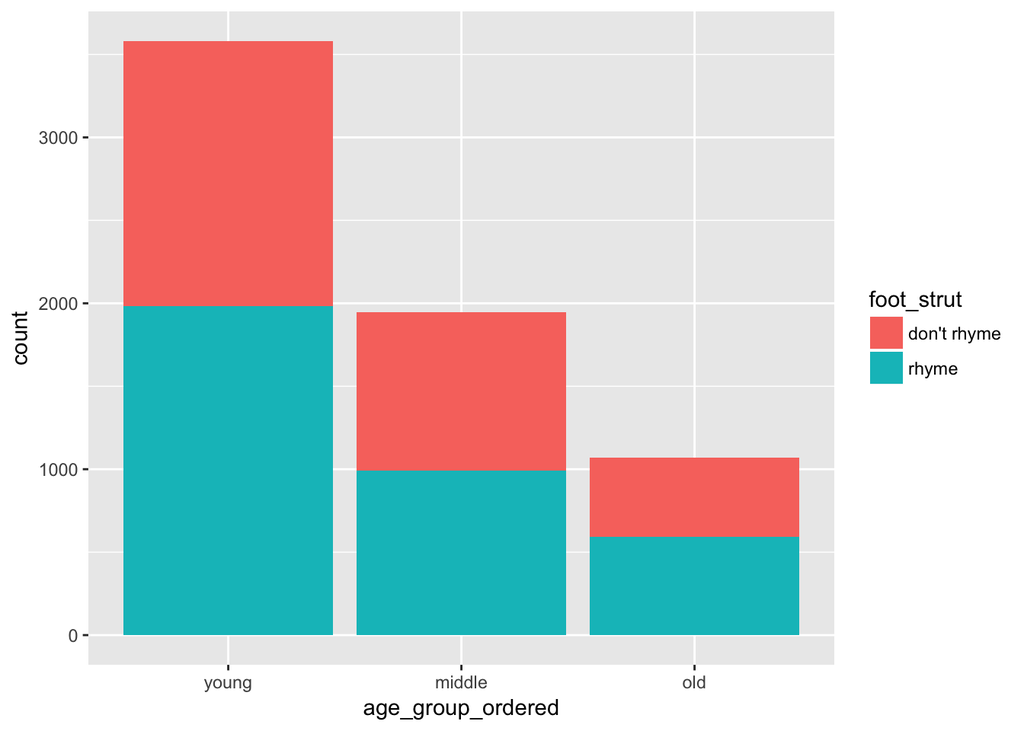

```r
ggplot(dialect_data, aes(age_group_ordered, fill = foot_strut)) +
  geom_bar()
```

This has given us the frequencies. Again, it’d be better to see the percentages, rather than the raw numbers. We can do this easily by adding `position="fill"` to the `geom_bar()` bit:

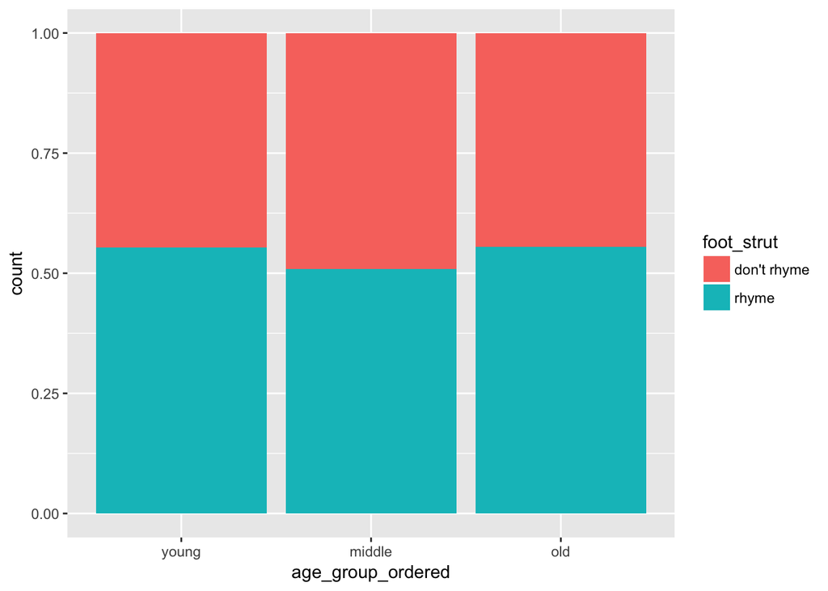

```r
ggplot(dialect_data, aes(age_group_ordered, fill = foot_strut)) +
  geom_bar(position="fill")
```

The beauty of ggplot is that you can just stack up command after command using the `+` symbol to customise your plot.

I can change the x axis title:

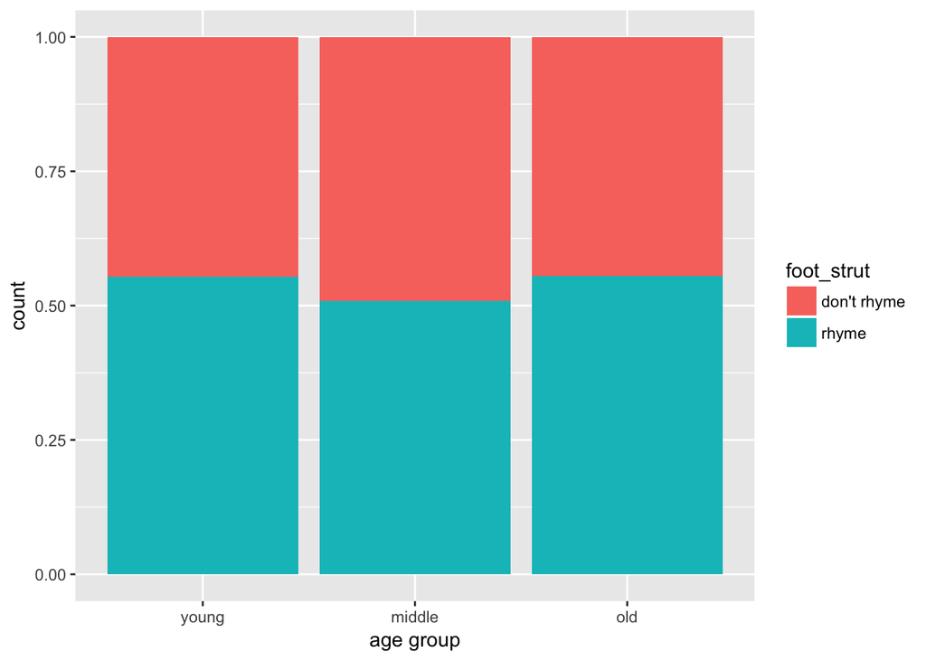

```r
ggplot(dialect_data, aes(age_group_ordered, fill = foot_strut)) +
  geom_bar(position="fill") +
  xlab("age group")
```

I can move the legend to the bottom:

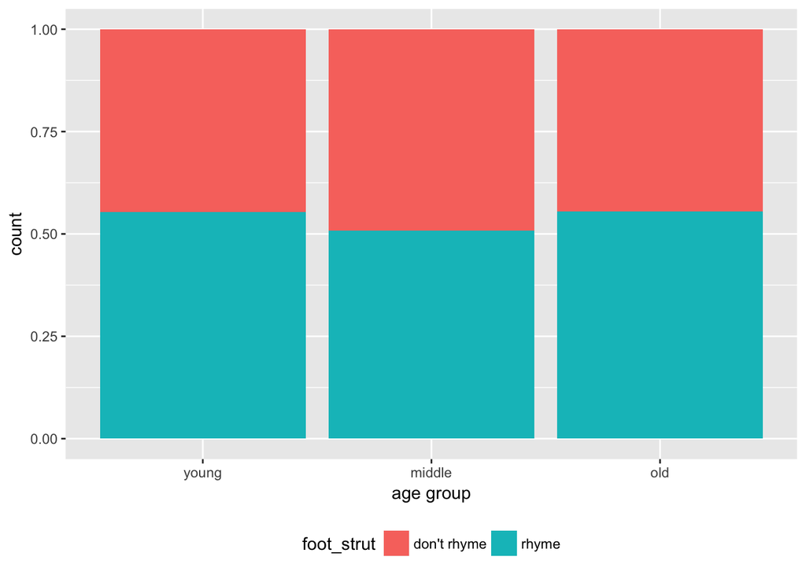

```r
ggplot(dialect_data, aes(age_group_ordered, fill = foot_strut)) +
  geom_bar(position="fill") +
  xlab("age group") +
  theme(legend.position = "bottom")
```

I can change the colours:

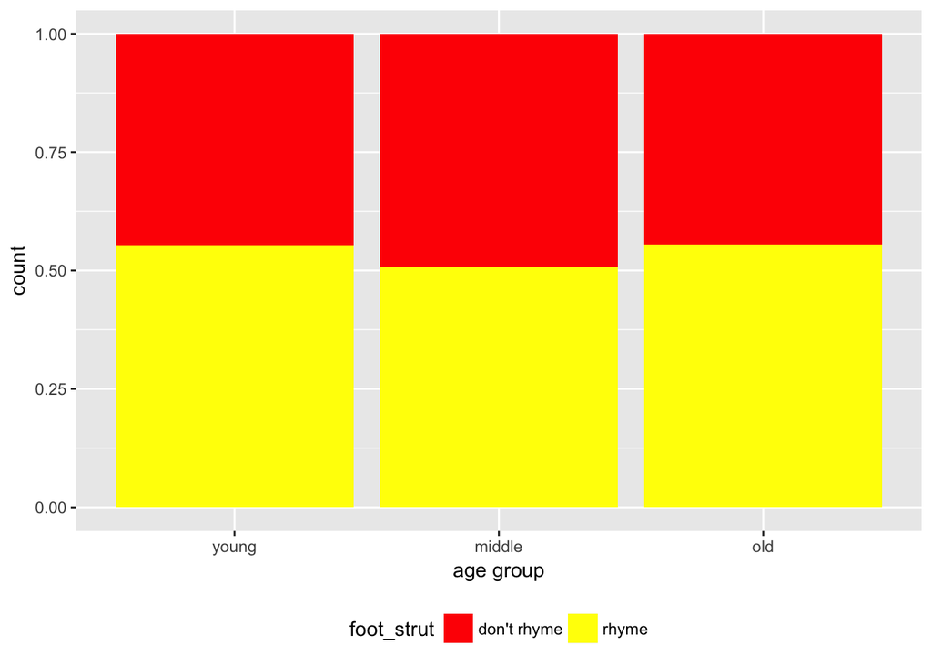

```r
ggplot(dialect_data, aes(age_group_ordered, fill = foot_strut)) +
  geom_bar(position="fill") +
  xlab("age group") +
  theme(legend.position = "bottom") +
  scale_fill_manual(values = c("red", "yellow"))
```

Try changing the colours yourself in the chunk below:

```r
#my ggplot with new colours
```

In fact, if you’re bad at choosing which colours go together, there are many in built colour palettes that you can use. A list can be found [here](https://www.nceas.ucsb.edu/~frazier/RSpatialGuides/colorPaletteCheatsheet.pdf) alongside the colour names that R accepts.

Let’s try a palette. I’m going to try Set1 from the above link. Try messing around with it to get a colour scheme you like.

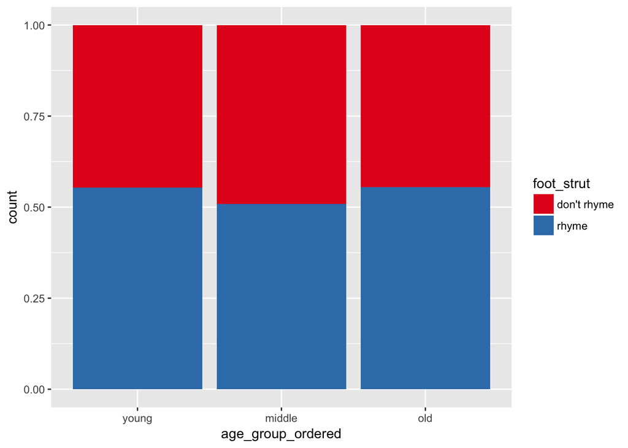

```r
ggplot(dialect_data, aes(age_group_ordered, fill = foot_strut)) +
  geom_bar(position="fill") +
  scale_fill_brewer(palette="Set1")
```

Try creating a plot from scratch using a different dependent variable. Our phonological variables are pretty orderly- they only have two factor levels, or variants. How do things start to look with some of our syntactic variables, or lexical? Try to make three plots: one new phonological, one new syntactic and one new lexical.

Once you’ve done that, you could look at other things that you can play around with in the settings of `ggplot2`. Here you can find the [ggplot cheat sheet](https://www.rstudio.com/wp-content/uploads/2015/03/ggplot2-cheatsheet.pdf).

Next week, we’ll be looking at how to automatically save figures to pdf.

# R markdown

You can convert this entire notebook into a pdf, html or Word document by going to the little triangle drop-down menu next to **Preview** and choosing one of the **Knit to…** options. This is how I’d like you to submit your assessment for class, but it is also handy for writing up your quantitative work, as your R code is embedded in your document.

As you start to publish your work, you won’t want the R code itself to show, but just the output. This is easy to do by setting the option `echo = FALSE`. Try previewing the document, or knitting the document to pdf, html or word, and compare the chunk below with earlier ones:

```
## [1] 4
```

Can you see this stops it from replicating the code?

Markdown is a very simple language. You use *stars for italics*, and you use **double stars for bold**. Hashes indicate new sections and the level of that section (i.e. two hashes are a subsection). Check out the R markdown cheatsheet [here](https://www.rstudio.com/wp-content/uploads/2015/02/rmarkdown-cheatsheet.pdf). You can see I just made a clickable link in the previous sentence. Have a look at what that looks like in your knitted output. For your next task, have a play around with different options in R markdown.